# HW3 Due: Dec 10, 2021

Dr. Xiang Ji @ Tulane

03 November, 2021

```r
rm(list = ls()) # clean-up workspace
```

## Acknowledgement

Dr. Hua Zhou’s [HW assignment](https://ucla-biostat-200c-2020spring.github.io/hw/hw1/hw1.html#q2.-cfr-of-covid-19)

## CFR of COVID-19

Of primary interest to public is the risk of dying from COVID-19. A commonly used measure is case fatality rate/ratio/risk (CFR), which is defined as
$$\frac{\text{number of deaths from disease}}{\text{number of diagnosed cases of disease}}.$$
Apparently CFR is not a fixed constant; it changes with time, location, and other factors. Also CFR is different from the infection fatality rate (IFR), the probability that someone infected with COVID-19 dies from it.

In this exercise, we use logistic regression to study how US county-level CFR changes according to demographic information and some health-, education-, and economy-indicators.

### Data sources

- `11-02-2021.csv`: The data on COVID-19 confirmed cases and deaths on 2021-11-02 is retrieved from the [Johns Hopkins COVID-19 data repository](https://github.com/CSSEGISandData/COVID-19). It was downloaded from this [link](https://github.com/CSSEGISandData/COVID-19/tree/master/csse_covid_19_data/csse_covid_19_daily_reports) (commit a94c128).
- `us-county-health-rankings-2020.csv.zip`: The 2020 County Health Ranking Data was released by [County Health Rankings](https://www.countyhealthrankings.org). The data was downloaded from the [Kaggle Uncover COVID-19 Challenge](https://www.kaggle.com/roche-data-science-coalition/uncover) (version 1).

### Sample code for data preparation

Load the `tidyverse` package for data manipulation and visualization.

```r
# tidyverse of data manipulation and visualization
library(tidyverse)
```

Read in the data of COVID-19 cases reported on 2021-11-02.

```r
county_count <- read_csv("./11-02-2021.csv") %>%
  # cast fips into dbl for use as a key for joining tables
  mutate(FIPS = as.numeric(FIPS)) %>%
  filter(Country_Region == "US") %>%
  print(width = Inf)
```

```
## # A tibble: 3,279 × 14
##     FIPS Admin2   Province_State Country_Region Last_Update           Lat Long_
##    <dbl> <chr>    <chr>          <chr>          <dttm>              <dbl> <dbl>
##  1  1001 Autauga  Alabama        US             2021-11-03 06:22:09  32.5 -86.6
##  2  1003 Baldwin  Alabama        US             2021-11-03 06:22:09  30.7 -87.7
##  3  1005 Barbour  Alabama        US             2021-11-03 06:22:09  31.9 -85.4
##  4  1007 Bibb     Alabama        US             2021-11-03 06:22:09  33.0 -87.1
##  5  1009 Blount   Alabama        US             2021-11-03 06:22:09  34.0 -86.6
##  6  1011 Bullock  Alabama        US             2021-11-03 06:22:09  32.1 -85.7
##  7  1013 Butler   Alabama        US             2021-11-03 06:22:09  31.8 -86.7
##  8  1015 Calhoun  Alabama        US             2021-11-03 06:22:09  33.8 -85.8
##  9  1017 Chambers Alabama        US             2021-11-03 06:22:09  32.9 -85.4
## 10  1019 Cherokee Alabama        US             2021-11-03 06:22:09  34.2 -85.6
##    Confirmed Deaths Recovered Active Combined_Key          Incident_Rate
##        <dbl>  <dbl> <lgl>     <lgl>  <chr>                         <dbl>
```

[output cut: 23 more lines]

Standardize the variable names by changing them to lower case.

```r
names(county_count) <- str_to_lower(names(county_count))
```

Sanity check by displaying the unique US states and territories:

```r
county_count %>%
  select(province_state) %>%
  distinct() %>%
  arrange(province_state) %>%
  print(n = Inf)
```

```
## # A tibble: 59 × 1
##    province_state
##    <chr>
##  1 Alabama
##  2 Alaska
##  3 American Samoa
##  4 Arizona
##  5 Arkansas
##  6 California
##  7 Colorado
##  8 Connecticut
##  9 Delaware
## 10 Diamond Princess
## 11 District of Columbia
## 12 Florida
```

[output cut: 47 more lines]

We want to exclude entries from `American Samoa`, `Diamond Princess`, `Grand Princess`, `Guam`, `Northern Mariana Islands`, `Puerto Rico`, `Recovered`, and `Virgin Islands`, and only consider counties from 50 states and DC.

```r
county_count <- county_count %>%
  filter(!(province_state %in% c("American Samoa", "Diamond Princess", "Grand Princess",
                                 "Recovered", "Guam", "Northern Mariana Islands",
                                 "Puerto Rico", "Virgin Islands"))) %>%
  print(width = Inf)
```

```
## # A tibble: 3,192 × 14
##     fips admin2   province_state country_region last_update           lat long_
##    <dbl> <chr>    <chr>          <chr>          <dttm>              <dbl> <dbl>
##  1  1001 Autauga  Alabama        US             2021-11-03 06:22:09  32.5 -86.6
##  2  1003 Baldwin  Alabama        US             2021-11-03 06:22:09  30.7 -87.7
##  3  1005 Barbour  Alabama        US             2021-11-03 06:22:09  31.9 -85.4
##  4  1007 Bibb     Alabama        US             2021-11-03 06:22:09  33.0 -87.1
##  5  1009 Blount   Alabama        US             2021-11-03 06:22:09  34.0 -86.6
##  6  1011 Bullock  Alabama        US             2021-11-03 06:22:09  32.1 -85.7
##  7  1013 Butler   Alabama        US             2021-11-03 06:22:09  31.8 -86.7
##  8  1015 Calhoun  Alabama        US             2021-11-03 06:22:09  33.8 -85.8
##  9  1017 Chambers Alabama        US             2021-11-03 06:22:09  32.9 -85.4
## 10  1019 Cherokee Alabama        US             2021-11-03 06:22:09  34.2 -85.6
##    confirmed deaths recovered active combined_key          incident_rate
##        <dbl>  <dbl> <lgl>     <lgl>  <chr>                         <dbl>
```

[output cut: 23 more lines]

Graphical summarize the COVID-19 confirmed cases and deaths on 2021-11-02 by state.

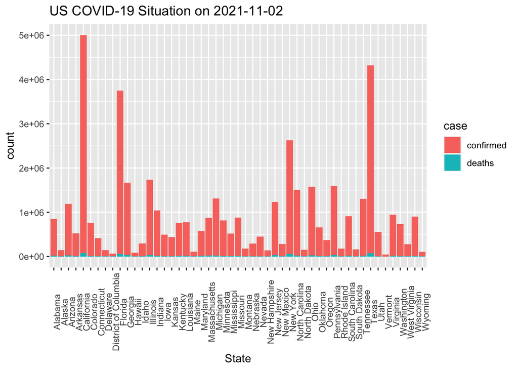

```r
county_count %>%
  # turn into long format for easy plotting
  pivot_longer(confirmed:recovered,
               names_to = "case",
               values_to = "count") %>%
  group_by(province_state) %>%
  ggplot() +
  geom_col(mapping = aes(x = province_state, y = `count`, fill = `case`)) +
  # scale_y_log10() +
  labs(title = "US COVID-19 Situation on 2021-11-02", x = "State") +
  theme(axis.text.x = element_text(angle = 90))
```

Read in the 2020 county-level health ranking data.

```r
county_info <- read_csv("./us-county-health-rankings-2020.csv") %>%
  filter(!is.na(county)) %>%
  # cast fips into dbl for use as a key for joining tables
  mutate(fips = as.numeric(fips)) %>%
  select(fips,
         state,
         county,
         percent_fair_or_poor_health,
         percent_smokers,
         percent_adults_with_obesity,
         # food_environment_index,
         percent_with_access_to_exercise_opportunities,
         percent_excessive_drinking,
         # teen_birth_rate,
         percent_uninsured,
         # primary_care_physicians_rate,
         # preventable_hospitalization_rate,
         # high_school_graduation_rate,
         percent_some_college,
         percent_unemployed,
         percent_children_in_poverty,
         # `80th_percentile_income`,
         # `20th_percentile_income`,
         percent_single_parent_households,
         # violent_crime_rate,
         percent_severe_housing_problems,
         overcrowding,
         # life_expectancy,
         # age_adjusted_death_rate,
         percent_adults_with_diabetes,
         # hiv_prevalence_rate,
         percent_food_insecure,
         # percent_limited_access_to_healthy_foods,
         percent_insufficient_sleep,
         percent_uninsured_2,
         median_household_income,
         average_traffic_volume_per_meter_of_major_roadways,
         percent_homeowners,
         # percent_severe_housing_cost_burden,
         population_2,
         percent_less_than_18_years_of_age,
         percent_65_and_over,
         percent_black,
         percent_asian,
         percent_hispanic,
         percent_female,
         percent_rural) %>%
  print(width = Inf)
```

```
## # A tibble: 3,142 × 30
##     fips state   county   percent_fair_or_poor_health percent_smokers
##    <dbl> <chr>   <chr>                          <dbl>           <dbl>
##  1  1001 Alabama Autauga                         20.9            18.1
##  2  1003 Alabama Baldwin                         17.5            17.5
##  3  1005 Alabama Barbour                         29.6            22.0
##  4  1007 Alabama Bibb                            19.4            19.1
##  5  1009 Alabama Blount                          21.7            19.2
##  6  1011 Alabama Bullock                         31.0            22.9
##  7  1013 Alabama Butler                          27.9            21.8
##  8  1015 Alabama Calhoun                         23.1            20.6
##  9  1017 Alabama Chambers                        24.0            19.4
## 10  1019 Alabama Cherokee                        20.7            17.5
##    percent_adults_with_obesity percent_with_access_to_exercise_opportunities
##                          <dbl>                                         <dbl>
```

[output cut: 107 more lines]

For stability in estimating CFR, we restrict to counties with $\ge 5$ confirmed cases.

```r
county_count <- county_count %>%
  filter(confirmed >= 5)
```

We join the COVID-19 count data and county-level information using FIPS (Federal Information Processing System) as key.

```r
county_data <- county_count %>%
  left_join(county_info, by = "fips") %>%
  print(width = Inf)
```

```
## # A tibble: 3,157 × 43
##     fips admin2   province_state country_region last_update           lat long_
##    <dbl> <chr>    <chr>          <chr>          <dttm>              <dbl> <dbl>
##  1  1001 Autauga  Alabama        US             2021-11-03 06:22:09  32.5 -86.6
##  2  1003 Baldwin  Alabama        US             2021-11-03 06:22:09  30.7 -87.7
##  3  1005 Barbour  Alabama        US             2021-11-03 06:22:09  31.9 -85.4
##  4  1007 Bibb     Alabama        US             2021-11-03 06:22:09  33.0 -87.1
##  5  1009 Blount   Alabama        US             2021-11-03 06:22:09  34.0 -86.6
##  6  1011 Bullock  Alabama        US             2021-11-03 06:22:09  32.1 -85.7
##  7  1013 Butler   Alabama        US             2021-11-03 06:22:09  31.8 -86.7
##  8  1015 Calhoun  Alabama        US             2021-11-03 06:22:09  33.8 -85.8
##  9  1017 Chambers Alabama        US             2021-11-03 06:22:09  32.9 -85.4
## 10  1019 Cherokee Alabama        US             2021-11-03 06:22:09  34.2 -85.6
##    confirmed deaths recovered active combined_key          incident_rate
##        <dbl>  <dbl> <lgl>     <lgl>  <chr>                         <dbl>
```

[output cut: 143 more lines]

Numerical summaries of each variable:

```r
summary(county_data)
```

```
##       fips          admin2          province_state     country_region
##  Min.   : 1001   Length:3157        Length:3157        Length:3157
##  1st Qu.:18592   Class :character   Class :character   Class :character
##  Median :29187   Mode  :character   Mode  :character   Mode  :character
##  Mean   :30842
##  3rd Qu.:46006
##  Max.   :90053
##  NA's   :10
##   last_update                       lat            long_
##  Min.   :2021-11-03 06:22:09   Min.   :19.60   Min.   :-174.16
##  1st Qu.:2021-11-03 06:22:09   1st Qu.:34.68   1st Qu.: -98.14
##  Median :2021-11-03 06:22:09   Median :38.37   Median : -90.30
##  Mean   :2021-11-03 06:22:09   Mean   :38.45   Mean   : -92.17
##  3rd Qu.:2021-11-03 06:22:09   3rd Qu.:41.83   3rd Qu.: -83.43
##  Max.   :2021-11-03 06:22:09   Max.   :69.31   Max.   : -67.63
##                                NA's   :33      NA's   :33
##    confirmed           deaths        recovered       active
##  Min.   :      8   Min.   :    0.0   Mode:logical   Mode:logical
##  1st Qu.:   1620   1st Qu.:   28.0   NA's:3157      NA's:3157
##  Median :   3921   Median :   66.0
##  Mean   :  14557   Mean   :  235.7
##  3rd Qu.:  10240   3rd Qu.:  162.0
##  Max.   :1495014   Max.   :26661.0
##
##  combined_key       incident_rate   case_fatality_ratio    state
##  Length:3157        Min.   : 1962   Min.   :   0.000    Length:3157
##  Class :character   1st Qu.:12824   1st Qu.:   1.193    Class :character
##  Mode  :character   Median :15077   Median :   1.632    Mode  :character
##                     Mean   :14994   Mean   :   2.902
##                     3rd Qu.:17153   3rd Qu.:   2.184
##                     Max.   :54277   Max.   :2829.070
##                     NA's   :33
##     county          percent_fair_or_poor_health percent_smokers
##  Length:3157        Min.   : 8.121              Min.   : 5.909
##  Class :character   1st Qu.:14.361              1st Qu.:14.989
##  Mode  :character   Median :17.261              Median :16.989
##                     Mean   :17.975              Mean   :17.525
##                     3rd Qu.:20.953              3rd Qu.:19.766
##                     Max.   :40.991              Max.   :41.491
##                     NA's   :43                  NA's   :43
```

[output cut: 65 more lines]

```
##  Min.   : 0.0000   Min.   : 0.0000   Min.   : 0.6105   Min.   :26.84
##  1st Qu.: 0.7283   1st Qu.: 0.4651   1st Qu.: 2.3948   1st Qu.:49.43
##  Median : 2.2841   Median : 0.7381   Median : 4.3525   Median :50.32
##  Mean   : 9.0652   Mean   : 1.5707   Mean   : 9.6658   Mean   :49.89
##  3rd Qu.:10.3587   3rd Qu.: 1.4350   3rd Qu.: 9.9949   3rd Qu.:51.03
##  Max.   :85.4143   Max.   :43.3570   Max.   :96.3595   Max.   :56.87
##  NA's   :43        NA's   :43        NA's   :43        NA's   :43
##  percent_rural
##  Min.   :  0.00
##  1st Qu.: 33.25
##  Median : 59.48
##  Mean   : 58.58
##  3rd Qu.: 87.67
##  Max.   :100.00
##  NA's   :49
```

List rows in `county_data` that don’t have a match in `county_count`:

```r
county_data %>%
  filter(is.na(state) & is.na(county)) %>%
  print(n = Inf)
```

```
## # A tibble: 43 × 43
##     fips admin2   province_state country_region last_update           lat  long_
##    <dbl> <chr>    <chr>          <chr>          <dttm>              <dbl>  <dbl>
##  1  2063 Chugach  Alaska         US             2021-11-03 06:22:09  61.2 -150.
##  2  2066 Copper … Alaska         US             2021-11-03 06:22:09  60.4 -163.
##  3 90002 Unassig… Alaska         US             2021-11-03 06:22:09  NA     NA
##  4 90005 Unassig… Arkansas       US             2021-11-03 06:22:09  NA     NA
##  5 90006 Unassig… California     US             2021-11-03 06:22:09  NA     NA
##  6 90008 Unassig… Colorado       US             2021-11-03 06:22:09  NA     NA
##  7 90009 Unassig… Connecticut    US             2021-11-03 06:22:09  NA     NA
##  8 90010 Unassig… Delaware       US             2021-11-03 06:22:09  NA     NA
##  9 90012 Unassig… Florida        US             2021-11-03 06:22:09  NA     NA
## 10 80013 Out of … Georgia        US             2021-11-03 06:22:09  NA     NA
## 11 90013 Unassig… Georgia        US             2021-11-03 06:22:09  NA     NA
## 12 80015 Out of … Hawaii         US             2021-11-03 06:22:09  NA     NA
```

[output cut: 38 more lines]

We found there are some rows that miss `fips`.

```r
county_count %>%
  filter(is.na(fips)) %>%
  select(fips, admin2, province_state) %>%
  print(n = Inf)
```

```
## # A tibble: 10 × 3
##     fips admin2                                    province_state
##    <dbl> <chr>                                     <chr>
##  1    NA Dukes and Nantucket                       Massachusetts
##  2    NA Federal Correctional Institution (FCI)    Michigan
##  3    NA Michigan Department of Corrections (MDOC) Michigan
##  4    NA Kansas City                               Missouri
##  5    NA Bear River                                Utah
##  6    NA Central Utah                              Utah
##  7    NA Southeast Utah                            Utah
##  8    NA Southwest Utah                            Utah
##  9    NA TriCounty                                 Utah
## 10    NA Weber-Morgan                              Utah
```

We need to (1) manually set the `fips` for some counties, (2) discard those `Unassigned`, `unassigned` or `Out of`, and (3) try to join with `county_info` again.

```r
county_data <- county_count %>%
  # manually set FIPS for some counties
  mutate(fips = ifelse(admin2 == "Dukes and Nantucket" & province_state == "Massachusetts", 25019, fips)) %>%
  mutate(fips = ifelse(admin2 == "Weber-Morgan" & province_state == "Utah", 49057, fips)) %>%
  # remove variable `recovered` and `active` because they are just columns of NAs
  mutate(recovered = NULL, active = NULL) %>%
  filter(!(is.na(fips) | str_detect(admin2, "Out of") | str_detect(admin2, "Unassigned"))) %>%
  left_join(county_info, by = "fips") %>%
  drop_na() %>%
  print(width = Inf)
```

```
## # A tibble: 3,109 × 41
##     fips admin2   province_state country_region last_update           lat long_
##    <dbl> <chr>    <chr>          <chr>          <dttm>              <dbl> <dbl>
##  1  1001 Autauga  Alabama        US             2021-11-03 06:22:09  32.5 -86.6
##  2  1003 Baldwin  Alabama        US             2021-11-03 06:22:09  30.7 -87.7
##  3  1005 Barbour  Alabama        US             2021-11-03 06:22:09  31.9 -85.4
##  4  1007 Bibb     Alabama        US             2021-11-03 06:22:09  33.0 -87.1
##  5  1009 Blount   Alabama        US             2021-11-03 06:22:09  34.0 -86.6
##  6  1011 Bullock  Alabama        US             2021-11-03 06:22:09  32.1 -85.7
##  7  1013 Butler   Alabama        US             2021-11-03 06:22:09  31.8 -86.7
##  8  1015 Calhoun  Alabama        US             2021-11-03 06:22:09  33.8 -85.8
##  9  1017 Chambers Alabama        US             2021-11-03 06:22:09  32.9 -85.4
## 10  1019 Cherokee Alabama        US             2021-11-03 06:22:09  34.2 -85.6
##    confirmed deaths combined_key          incident_rate case_fatality_ratio
##        <dbl>  <dbl> <chr>                         <dbl>               <dbl>
```

[output cut: 131 more lines]

Summarize again

```r
summary(county_data)
```

```
##       fips          admin2          province_state     country_region
##  Min.   : 1001   Length:3109        Length:3109        Length:3109
##  1st Qu.:18179   Class :character   Class :character   Class :character
##  Median :29163   Mode  :character   Mode  :character   Mode  :character
##  Mean   :30326
##  3rd Qu.:45051
##  Max.   :56045
##   last_update                       lat            long_
##  Min.   :2021-11-03 06:22:09   Min.   :19.60   Min.   :-174.16
##  1st Qu.:2021-11-03 06:22:09   1st Qu.:34.65   1st Qu.: -98.07
##  Median :2021-11-03 06:22:09   Median :38.35   Median : -90.21
##  Mean   :2021-11-03 06:22:09   Mean   :38.40   Mean   : -92.01
##  3rd Qu.:2021-11-03 06:22:09   3rd Qu.:41.80   3rd Qu.: -83.40
##  Max.   :2021-11-03 06:22:09   Max.   :69.31   Max.   : -67.63
##    confirmed           deaths        combined_key       incident_rate
##  Min.   :     19   Min.   :    0.0   Length:3109        Min.   : 1962
##  1st Qu.:   1644   1st Qu.:   28.0   Class :character   1st Qu.:12829
##  Median :   3941   Median :   67.0   Mode  :character   Median :15074
##  Mean   :  14650   Mean   :  229.9                      Mean   :14998
##  3rd Qu.:  10275   3rd Qu.:  164.0                      3rd Qu.:17168
##  Max.   :1495014   Max.   :26661.0                      Max.   :54277
##  case_fatality_ratio    state              county
##  Min.   :0.000       Length:3109        Length:3109
##  1st Qu.:1.209       Class :character   Class :character
##  Median :1.641       Mode  :character   Mode  :character
##  Mean   :1.768
##  3rd Qu.:2.189
##  Max.   :7.628
##  percent_fair_or_poor_health percent_smokers  percent_adults_with_obesity
##  Min.   : 8.121              Min.   : 5.909   Min.   :12.4
##  1st Qu.:14.361              1st Qu.:14.987   1st Qu.:29.3
##  Median :17.260              Median :16.985   Median :33.1
##  Mean   :17.968              Mean   :17.508   Mean   :32.9
##  3rd Qu.:20.950              3rd Qu.:19.755   3rd Qu.:36.6
##  Max.   :40.991              Max.   :41.491   Max.   :57.7
##  percent_with_access_to_exercise_opportunities percent_excessive_drinking
##  Min.   :  0.00                                Min.   : 7.81
##  1st Qu.: 48.52                                1st Qu.:15.34
##  Median : 65.82                                Median :17.58
##  Mean   : 62.79                                Mean   :17.54
```

[output cut: 43 more lines]

```
##  Max.   :92.40      Max.   :10105518   Max.   :41.992
##  percent_65_and_over percent_black     percent_asian     percent_hispanic
##  Min.   : 4.83       Min.   : 0.0000   Min.   : 0.0000   Min.   : 0.6105
##  1st Qu.:16.30       1st Qu.: 0.7307   1st Qu.: 0.4654   1st Qu.: 2.3926
##  Median :18.93       Median : 2.3228   Median : 0.7383   Median : 4.3532
##  Mean   :19.29       Mean   : 9.0803   Mean   : 1.5709   Mean   : 9.6791
##  3rd Qu.:21.81       3rd Qu.:10.3662   3rd Qu.: 1.4353   3rd Qu.:10.0066
##  Max.   :57.59       Max.   :85.4143   Max.   :43.3570   Max.   :96.3595
##  percent_female  percent_rural
##  Min.   :26.84   Min.   :  0.00
##  1st Qu.:49.43   1st Qu.: 33.15
##  Median :50.32   Median : 59.45
##  Mean   :49.90   Mean   : 58.54
##  3rd Qu.:51.03   3rd Qu.: 87.30
##  Max.   :56.87   Max.   :100.00
```

If there are variables with missing value for many counties, we go back and remove those variables from consideration.

Let’s create a final data frame for analysis.

```r
county_data <- county_data %>%
  mutate(state = as.factor(state)) %>%
  select(county, confirmed, deaths, state, percent_fair_or_poor_health:percent_rural)
summary(county_data)
```

```
##     county            confirmed           deaths             state
##  Length:3109        Min.   :     19   Min.   :    0.0   Texas   : 253
##  Class :character   1st Qu.:   1644   1st Qu.:   28.0   Georgia : 159
##  Mode  :character   Median :   3941   Median :   67.0   Virginia: 133
##                     Mean   :  14650   Mean   :  229.9   Kentucky: 120
##                     3rd Qu.:  10275   3rd Qu.:  164.0   Missouri: 115
##                     Max.   :1495014   Max.   :26661.0   Kansas  : 105
##                                                         (Other) :2224
##  percent_fair_or_poor_health percent_smokers  percent_adults_with_obesity
##  Min.   : 8.121              Min.   : 5.909   Min.   :12.4
##  1st Qu.:14.361              1st Qu.:14.987   1st Qu.:29.3
##  Median :17.260              Median :16.985   Median :33.1
##  Mean   :17.968              Mean   :17.508   Mean   :32.9
##  3rd Qu.:20.950              3rd Qu.:19.755   3rd Qu.:36.6
##  Max.   :40.991              Max.   :41.491   Max.   :57.7
##
##  percent_with_access_to_exercise_opportunities percent_excessive_drinking
##  Min.   :  0.00                                Min.   : 7.81
##  1st Qu.: 48.52                                1st Qu.:15.34
##  Median : 65.82                                Median :17.58
##  Mean   : 62.79                                Mean   :17.54
##  3rd Qu.: 80.09                                3rd Qu.:19.68
##  Max.   :100.00                                Max.   :28.62
##
##  percent_uninsured percent_some_college percent_unemployed
##  Min.   : 2.263    Min.   :15.18        Min.   : 1.302
##  1st Qu.: 7.376    1st Qu.:49.80        1st Qu.: 3.120
##  Median :10.528    Median :57.93        Median : 3.873
##  Mean   :11.452    Mean   :57.85        Mean   : 4.117
##  3rd Qu.:14.445    3rd Qu.:66.47        3rd Qu.: 4.814
##  Max.   :33.750    Max.   :90.67        Max.   :18.092
##
##  percent_children_in_poverty percent_single_parent_households
##  Min.   : 2.50               Min.   : 0.00
##  1st Qu.:14.60               1st Qu.:25.62
##  Median :20.10               Median :31.70
##  Mean   :21.15               Mean   :32.44
##  3rd Qu.:26.40               3rd Qu.:37.70
##  Max.   :68.30               Max.   :87.20
##
```

[output cut: 33 more lines]

```
##  Min.   : 4.83       Min.   : 0.0000   Min.   : 0.0000   Min.   : 0.6105
##  1st Qu.:16.30       1st Qu.: 0.7307   1st Qu.: 0.4654   1st Qu.: 2.3926
##  Median :18.93       Median : 2.3228   Median : 0.7383   Median : 4.3532
##  Mean   :19.29       Mean   : 9.0803   Mean   : 1.5709   Mean   : 9.6791
##  3rd Qu.:21.81       3rd Qu.:10.3662   3rd Qu.: 1.4353   3rd Qu.:10.0066
##  Max.   :57.59       Max.   :85.4143   Max.   :43.3570   Max.   :96.3595
##
##  percent_female  percent_rural
##  Min.   :26.84   Min.   :  0.00
##  1st Qu.:49.43   1st Qu.: 33.15
##  Median :50.32   Median : 59.45
##  Mean   :49.90   Mean   : 58.54
##  3rd Qu.:51.03   3rd Qu.: 87.30
##  Max.   :56.87   Max.   :100.00
##
```

Display the 10 counties with highest CFR.

```r
county_data %>%
  mutate(cfr = deaths / confirmed) %>%
  select(county, state, confirmed, deaths, cfr) %>%
  arrange(desc(cfr)) %>%
  top_n(10)
```

```
## # A tibble: 10 × 5
##    county   state        confirmed deaths    cfr
##    <chr>    <fct>            <dbl>  <dbl>  <dbl>
##  1 Sabine   Texas              957     73 0.0763
##  2 Hancock  Georgia           1121     81 0.0723
##  3 McMullen Texas              117      8 0.0684
##  4 Harding  New Mexico          44      3 0.0682
##  5 Knox     Texas              351     21 0.0598
##  6 Jerauld  South Dakota       301     17 0.0565
##  7 Motley   Texas              161      9 0.0559
##  8 Candler  Georgia           1560     87 0.0558
##  9 Twiggs   Georgia           1084     60 0.0554
## 10 Foard    Texas              181     10 0.0552
```

Write final data into a csv file for future use.

```r
write_csv(county_data, "covid19-county-data-20211102.csv.gz")
```

### 1

Read and run above code to generate a data frame `county_data` that includes county-level COVID-19 confirmed cases and deaths, demographic, and health related information.

### 2

What assumptions of CFR might be violated by defining CFR as `deaths/confirmed` from this data set? With acknowledgement of these severe limitations, we continue to use `deaths/confirmed` as a very rough proxy of CFR.

### 3

What assumptions of logistic regression may be violated by this data set?

### 4

Run a binomial regression, using variables `state`, …, `percent_rural` as predictors.

### 5

Interpret the regression coefficients of 3 significant predictors with p-value <0.01.

### 6

Apply analysis of deviance to (1) evaluate the goodness of fit of the model and (2) compare the model to the intercept-only model.

### 7

Perform analysis of deviance to evaluate the significance of each predictor. Display the 10 most significant predictors.

### 8

Construct confidence intervals of regression coefficients.

### 9

Plot the deviance residuals against the fitted values. Are there potential outliers?

### 10

Plot the half-normal plot. Are there potential outliers in predictor space?

### 11

Find the best sub-model using the AIC criterion.

### 12

Find the best sub-model using the lasso with cross validation.